## Predictions

In thinking about predictions, there are a few things to point out:

- Voting rates in midterm elections in these counties has been decreasing over the past 15 years
  - Turnout in 2014 was far lower than in 2010, 2006, and 2002
- Roughly half of the people who turn out for general elections vote in midterms
- Redistricting has made my predictions very approximate, as I incorporate data from House and Senate midterms of the same year

Let’s make some predictions:

- Taking half of the electorate in the 2016 presidential election, we get **38,350 voters** expected in 2018.
  - 2014 had 41,484 voters, so this would follow the decreasing participation rate in Midterms
- If we take the average of Midterm voters from 2002 to 2014 in the 5 counties, we get **48,500 voters.**

So these are some nice wide bounds, but we want a more accurate estimate.

## Plots of Votes (including 2018 Projected), by County

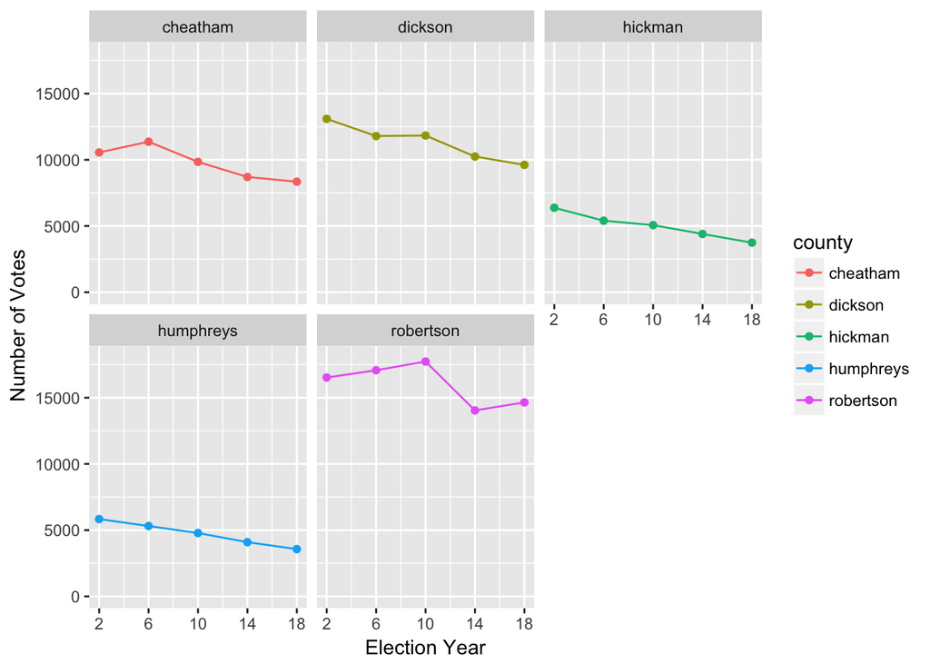

## Table of Projections

| County | LinearProjection | TurnoutProjection |
| --- | --- | --- |
| cheatham | 8347 | 8824 |
| dickson | 9618 | 10811 |
| hickman | 3742 | 4413 |
| humphreys | 3568 | 4151 |
| robertson | 14645 | 14653 |
| **TOTAL** | **39920** | **42852** |